# 21090478_coursework-1

```python
"""
cw1 for Risk Analysis and Quantitative Asset Allocation 2021/22
student_id: 21090478

require packages: matplotlib & scipy & seaborn
pip install matplotlib
pip install scipy
pip install seaborn
"""

#import yfinance as yf  # an API fo yahoo finance database
#import yahoo_finance as yh
from yahoo_fin.stock_info import get_data
import pandas as pd
import numpy as np
import matplotlib.pyplot as plt
import scipy
import seaborn as sns
```

### Q1:

Download month-end closing-price time-series data for the following indices2, starting at 30/Sept/2003

- Fixed income part: iShares Core US Aggregate Bond ETF (AGG)
- Equity part: S&P 500 Index (S&P)

```python
"""
In the part, the codes provide two ways to download data:
(1) the fist way is:  call the function " get_month_end_data_from_api". The function can download data from yahoo_fin api.
(2) the second way is: read data from data_IH.xlsx
"""

# -------------------------------------------------------------------------------------------
# Way (1): Download data from API: (Here I transfrom the codes into comments. If you want to use way(1), please transfrom the comments into codes)
def get_month_end_data_from_api(symbol):
    data = get_data(symbol,start_date='2003-09-03',interval="1d")
    #data['Date'] = data.index.values
    data['Year'] = data['Date'].apply(lambda x: x.year)
    data['Month'] = data['Date'].apply(lambda x: x.month)
    data = data.sort_values(['Date'])
    data_monthly = data.groupby(['Year','Month']).apply(lambda df: df.iloc[-1,:])
    data_monthly.index = data_monthly['Date']
    return(
        data_monthly
    )
# data_AGG = get_month_end_data_from_api('AGG')
# data_SP = get_month_end_data_from_api('^GSPC')

# # Menge AGG data & SP data into one dataframe
# data = pd.merge(data_AGG[['close']],
#                 data_SP[['close']],
#                 left_index = True,
#                 right_index = True,
#                 how='left'
# )
# data.columns = ['AGG', 'SP'] # rename columns
# data
# -------------------------------------------------------------------------------------------



# -------------------------------------------------------------------------------------------
# Way (2): read data from data_IH.xlsx: (If you can't run the codes, please check the file path firstly)
def get_month_end_data(data):
    data['Year'] = data['Date'].apply(lambda x: x.year)
    data['Month'] = data['Date'].apply(lambda x: x.month)
    data = data.sort_values(['Date'])
    data_month_end = data.groupby(['Year','Month']).apply(lambda df: df.iloc[-1,:])
    data_month_end.index = data_month_end['Date']
    return(
        data_month_end
    )

data = pd.read_excel("data_IH.xlsx")  # please check the file path according to your environment.
data = get_month_end_data(data)[['Fixed Income','Equity']].rename({'Fixed Income':'close_AGG','Equity':'close_SP'},axis=1)
data
# -------------------------------------------------------------------------------------------
```

| Date | close_AGG | close_SP |
| --- | --- | --- |
| 2003-09-30 | 57.482021 | 995.97 |
| 2003-10-31 | 56.944702 | 1050.71 |
| 2003-11-28 | 57.135136 | 1058.20 |
| 2003-12-31 | 57.694630 | 1111.92 |
| 2004-01-30 | 57.948776 | 1131.13 |
| ... | ... | ... |
| 2021-09-30 | 114.026978 | 4307.54 |
| 2021-10-29 | 114.017029 | 4605.38 |
| 2021-11-30 | 114.325836 | 4567.00 |
| 2021-12-31 | 113.915718 | 4766.18 |
| 2022-01-31 | 111.639008 | 4515.55 |

221 rows × 2 columns

### Q2:

Create a return index time-series of 60% S&P + 40% AGG, rebalanced monthly. Base it at 100 on 30/Sept/2003. [10 points]

- The formula for calculating continuous return: $r = \ln(p_{t}/p_{t-1})$
- The formula for calculating portfolio return: (continuous return): $r_p = \ln( w_A * e^{r_A} + w_B * e^{r_B})$
- The formula for calculating portfolio return: (simple return): $r_p = w_A * r_A + w_B * r_B$

```python
data_month = data.copy()

# calculate the continuous return: r = log(p_{t}/p_{t-1})
data_month['return_AGG'] = np.log( data_month['close_AGG'] / data_month['close_AGG'].shift()  )
data_month['return_SP'] = np.log( data_month['close_SP'] / data_month['close_SP'].shift() )

# calculate the portfolio return: the weights remain 0.6 and 0.4 repectively, because we assume the portfolio is rebalanced monthly.
data_month['return_40/60'] = np.log( 0.4 * np.exp(data_month['return_AGG']) + 0.6 * np.exp(data_month['return_SP']))

# calculate the index (base at 100 on 30 Sep 2003)
data_month['index_AGG'] = data_month['close_AGG']/data_month['close_AGG'][0] * 100
data_month['index_SP'] = data_month['close_SP']/data_month['close_SP'][0] * 100
data_month['index_40/60'] = 100 * np.exp( data_month['return_40/60'].cumsum() )
data_month.loc[data_month.index[0],'index_40/60'] = 100

# show the result
data_month
```

| Date | close_AGG | close_SP | return_AGG | return_SP | return_40/60 | index_AGG | index_SP | index_40/60 |
| --- | --- | --- | --- | --- | --- | --- | --- | --- |
| 2003-09-30 | 57.482021 | 995.97 | NaN | NaN | NaN | 100.000000 | 100.000000 | 100.000000 |
| 2003-10-31 | 56.944702 | 1050.71 | -0.009392 | 0.053504 | 0.028819 | 99.065240 | 105.496149 | 102.923786 |
| 2003-11-28 | 57.135136 | 1058.20 | 0.003339 | 0.007103 | 0.005599 | 99.396533 | 106.248180 | 103.501681 |
| 2003-12-31 | 57.694630 | 1111.92 | 0.009745 | 0.049519 | 0.033799 | 100.369870 | 111.641917 | 107.059681 |
| 2004-01-30 | 57.948776 | 1131.13 | 0.004395 | 0.017129 | 0.012055 | 100.812002 | 113.570690 | 108.358086 |
| ... | ... | ... | ... | ... | ... | ... | ... | ... |
| 2021-09-30 | 114.026978 | 4307.54 | -0.009215 | -0.048738 | -0.032741 | 198.369814 | 432.496963 | 331.841752 |
| 2021-10-29 | 114.017029 | 4605.38 | -0.000087 | 0.066858 | 0.040615 | 198.352506 | 462.401478 | 345.597065 |
| 2021-11-30 | 114.325836 | 4567.00 | 0.002705 | -0.008369 | -0.003925 | 198.889729 | 458.547948 | 344.243407 |
| 2021-12-31 | 113.915718 | 4766.18 | -0.003594 | 0.042689 | 0.024432 | 198.176258 | 478.546543 | 352.757516 |
| 2022-01-31 | 111.639008 | 4515.55 | -0.020188 | -0.054018 | -0.040349 | 194.215523 | 453.382130 | 338.807572 |

221 rows × 8 columns

### Additional Q: How to implement rebalancing:

- In this part, the codes show how to implement rebalancing

```python
# Prepare initial information:

data[['close_AGG','close_SP']]  # the price data; based at 100 on 2003-09-30

initial_portfolio_asset_amout = 10000 # we assume the portfolio asset amout is 10000 unit
initial_weight_AGG = 0.4 # we assume the initial weight of AGG is 0.4
initial_weight_SP = 0.6# we assume the initial weight of SP is 0.6

initial_quantity_AGG = initial_portfolio_asset_amout * initial_weight_AGG / data['close_AGG'][0]
initial_quantity_SP = initial_portfolio_asset_amout * initial_weight_SP / data['close_SP'][0]

# initial information
data_rebalance_initial = pd.DataFrame({
    'price_AGG' : data['close_AGG'].values,
    'price_SP' : data['close_SP'].values,
    'sell/buy_quantity_AGG':np.NaN,
    'sell/buy_quantity_SP':np.NaN,
    'quantity_AGG' : np.NaN,
    'quantity_SP' : np.NaN,
    'weight_AGG': np.NaN,
    'weight_SP': np.NaN,
    '40/60 asset amount': np.NaN
},index=data.index)
data_rebalance_initial.iloc[0,4:] = [initial_quantity_AGG, initial_quantity_SP, initial_weight_AGG, initial_weight_SP, initial_portfolio_asset_amout]

print('The initial information about rebalancing:')
data_rebalance_initial # this will show all the initial information
```

```
The initial information about rebalancing:
```

| Date | price_AGG | price_SP | sell/buy_quantity_AGG | sell/buy_quantity_SP | quantity_AGG | quantity_SP | weight_AGG | weight_SP | 40/60 asset amount |
| --- | --- | --- | --- | --- | --- | --- | --- | --- | --- |
| 2003-09-30 | 57.482021 | 995.97 | NaN | NaN | 69.586976 | 6.024278 | 0.4 | 0.6 | 10000.0 |
| 2003-10-31 | 56.944702 | 1050.71 | NaN | NaN | NaN | NaN | NaN | NaN | NaN |
| 2003-11-28 | 57.135136 | 1058.20 | NaN | NaN | NaN | NaN | NaN | NaN | NaN |
| 2003-12-31 | 57.694630 | 1111.92 | NaN | NaN | NaN | NaN | NaN | NaN | NaN |
| 2004-01-30 | 57.948776 | 1131.13 | NaN | NaN | NaN | NaN | NaN | NaN | NaN |
| ... | ... | ... | ... | ... | ... | ... | ... | ... | ... |
| 2021-09-30 | 114.026978 | 4307.54 | NaN | NaN | NaN | NaN | NaN | NaN | NaN |
| 2021-10-29 | 114.017029 | 4605.38 | NaN | NaN | NaN | NaN | NaN | NaN | NaN |
| 2021-11-30 | 114.325836 | 4567.00 | NaN | NaN | NaN | NaN | NaN | NaN | NaN |
| 2021-12-31 | 113.915718 | 4766.18 | NaN | NaN | NaN | NaN | NaN | NaN | NaN |
| 2022-01-31 | 111.639008 | 4515.55 | NaN | NaN | NaN | NaN | NaN | NaN | NaN |

221 rows × 9 columns

```python
# Rebalance Process
target_propotion_AGG = 0.4
target_propotion_SP = 0.6

df = data_rebalance_initial.copy()
for current_date, last_date in zip(df.index[1:], df.index[:-1]):
    # calculate the portfolio asset amount
    df.loc[current_date,'40/60 asset amount'] = (df.loc[last_date,'quantity_AGG'] * df.loc[current_date,'price_AGG'] +
                                             df.loc[last_date,'quantity_SP'] * df.loc[current_date,'price_SP'] )
    # the weight should be fixed at the same value as target weight
    df.loc[current_date,'weight_AGG'] = target_propotion_AGG
    df.loc[current_date,'weight_SP'] = target_propotion_SP

    # in order to fix the weight, we need to achieve the corresponding quantity of each asset in the portfolio
    df.loc[current_date,'quantity_AGG'] = df.loc[current_date,'40/60 asset amount'] * df.loc[current_date,'weight_AGG'] / df.loc[current_date,'price_AGG']
    df.loc[current_date,'quantity_SP'] = df.loc[current_date,'40/60 asset amount'] * df.loc[current_date,'weight_SP'] / df.loc[current_date,'price_SP']

    # in order to the realize the quantity we need, we should do some trades
    df.loc[current_date,'sell/buy_quantity_AGG'] = df.loc[current_date,'quantity_AGG'] - df.loc[last_date,'quantity_AGG']
    df.loc[current_date,'sell/buy_quantity_SP'] = df.loc[current_date,'quantity_SP'] - df.loc[last_date,'quantity_SP']

#df['real_weight_AGG'] = df['quantity_AGG'] * df['price_AGG'] / df['40/60 asset amount']
#df['real_weight_SP'] = df['quantity_SP'] * df['price_SP'] / df['40/60 asset amount']

print('The information about implementing rebalancing:')
df
```

```
The information about implementing rebalancing:
```

| Date | price_AGG | price_SP | sell/buy_quantity_AGG | sell/buy_quantity_SP | quantity_AGG | quantity_SP | weight_AGG | weight_SP | 40/60 asset amount |
| --- | --- | --- | --- | --- | --- | --- | --- | --- | --- |
| 2003-09-30 | 57.482021 | 995.97 | NaN | NaN | 69.586976 | 6.024278 | 0.4 | 0.6 | 10000.000000 |
| 2003-10-31 | 56.944702 | 1050.71 | 2.710381 | -0.146893 | 72.297357 | 5.877385 | 0.4 | 0.6 | 10292.378565 |
| 2003-11-28 | 57.135136 | 1058.20 | 0.163611 | -0.008834 | 72.460967 | 5.868551 | 0.4 | 0.6 | 10350.168053 |
| 2003-12-31 | 57.694630 | 1111.92 | 1.764090 | -0.091534 | 74.225058 | 5.777017 | 0.4 | 0.6 | 10705.968097 |
| 2004-01-30 | 57.948776 | 1131.13 | 0.570714 | -0.029238 | 74.795772 | 5.747779 | 0.4 | 0.6 | 10835.808597 |
| ... | ... | ... | ... | ... | ... | ... | ... | ... | ... |
| 2021-09-30 | 114.026978 | 4307.54 | -2.771086 | 0.073355 | 116.408155 | 4.622245 | 0.4 | 0.6 | 33184.175233 |
| 2021-10-29 | 114.017029 | 4605.38 | 4.835862 | -0.119723 | 121.244017 | 4.502522 | 0.4 | 0.6 | 34559.706533 |
| 2021-11-30 | 114.325836 | 4567.00 | -0.801108 | 0.020054 | 120.442909 | 4.522576 | 0.4 | 0.6 | 34424.340747 |
| 2021-12-31 | 113.915718 | 4766.18 | 3.423234 | -0.081818 | 123.866143 | 4.440758 | 0.4 | 0.6 | 35275.751623 |
| 2022-01-31 | 111.639008 | 4515.55 | -2.472169 | 0.061120 | 121.393974 | 4.501878 | 0.4 | 0.6 | 33880.757211 |

221 rows × 9 columns

### Q3:

Calculate the annualised return and volatility of three portfolios, i.e. AGG, S&P, and 60/40, and return correlations between AGG and S&P in the following way [20 points]:

- First half of the sample and second half of the sample
- Entire sample period
- holding-period return: $$ r_h = \frac{P_{end}-P_0}{P_0}$$
- annulized return: $$ \begin{aligned} P_{end} = P_0 \exp(r \frac{n}{12}) & = P_0 \exp( \sum \limits_{i=1}^{n} r_{i,monthly} 1_{month} ) \\ & =P_0 \exp( \sum \limits_{i=1}^{n} r_{ \text{ i, annulized monthly}} \frac{1}{12} ) \\ r_{ \text{ i, annulized monthly}} & = 12 r_{ \text{ i, monthly}}\\ r & = \frac{1}{n} \sum \limits_{i=1}^{n} r_{\text{ i, annulized monthly}} \end{aligned} $$
- annulized volatility of monthly return:

$$ \sigma_{\text{yearly}} = \sqrt{12}\sigma_{ \text{monthly}} $$

```python
# Annualise the return:  exp(r_month* 1 month * 12) = exp(r_year * 1 year)  ==>  r_year = r_month * 12
def calculate_return_and_volatility(df):
    return([
        # holding perioud return
        (df['close_AGG'][-1] - df['close_AGG'][0]) / df['close_AGG'][0] ,
        (df['close_SP'][-1] - df['close_SP'][0]) / df['close_SP'][0] ,
        (df['index_40/60'][-1] - df['index_40/60'][0]) / df['index_40/60'][0] ,
        '-',
        # annulized holding-period return
        np.nanmean( 12 * df['return_AGG']  ),
        np.nanmean( 12 * df['return_SP'] ),
        np.nanmean( 12 * df['return_40/60'] ),
        '-',
        # volatility
        np.std(df['return_AGG'].dropna(), ddof=1) * np.sqrt(12),
        np.std(df['return_SP'].dropna(), ddof=1) * np.sqrt(12),
        np.std(df['return_40/60'].dropna(), ddof=1) * np.sqrt(12),
        '-',
        # correlation
        df[['return_AGG','return_SP']].corr().values[0][1]
    ])

breakpoint = int(data_month.shape[0]/2)  # calculate the breakpoint

data_volatility_for_annul_return = pd.DataFrame(
    {
        'entire sample': calculate_return_and_volatility(data_month),
        'the first half of the sample': calculate_return_and_volatility(data_month[:breakpoint]),
        'the second half of the sample': calculate_return_and_volatility(data_month[breakpoint:])
    },
    index = ['holding_period_return_AGG',
             'holding_period_return_SP',
             'holding_period_return_40/60',
             '-',
             'annulized_return_AGG',
             'annulized_return_SP',
             'annulized_return_40/60',
             '-',
             'annulized volatility of monthly_R_AGG',
             'annulized volatility of monthly_R_SP',
             'annulized volatility of monthly_R_40/60',
             '-',
             'correlation coefficient of monthly_a.R_AGG & monthly_a.R_SP']
)

data_volatility_for_annul_return
```

|  | entire sample | the first half of the sample | the second half of the sample |
| --- | --- | --- | --- |
| holding_period_return_AGG | 0.942155 | 0.557448 | 0.243646 |
| holding_period_return_SP | 3.533821 | 0.417874 | 2.188542 |
| holding_period_return_40/60 | 2.388076 | 0.511508 | 1.235282 |
| - | - | - | - |
| annulized_return_AGG | 0.036207 | 0.048776 | 0.023865 |
| annulized_return_SP | 0.082449 | 0.038439 | 0.125666 |
| annulized_return_40/60 | 0.06656 | 0.04548 | 0.08726 |
| - | - | - | - |
| annulized volatility of monthly_R_AGG | 0.03628 | 0.039769 | 0.032277 |
| annulized volatility of monthly_R_SP | 0.144323 | 0.154104 | 0.13355 |
| annulized volatility of monthly_R_40/60 | 0.088061 | 0.094339 | 0.081414 |
| - | - | - | - |
| correlation coefficient of monthly_a.R_AGG & monthly_a.R_SP | 0.049906 | 0.077597 | 0.033373 |

### Q4:

Create monthly return distributions of AGG, S&P, and 60/40 portfolios from the entire sample and compare their statistical properties [20 points]

- Skewness: $$ S = E[(\frac{X-\mu}{\sigma})^3]$$
- sample skewness: $$ \hat{S} = \frac{1}{n-2}\sum_{i=1}^{n}(\frac{X_i-\hat{\mu}}{ \hat{\sigma}})^3$$
- Kurtosis: $$ K = E[(\frac{X-\mu}{\sigma})^4] $$
- excess Kurtosis: $$ K_{excess} = K -3 $$
- sample skewness: $$ \hat{K} = \frac{1}{n-2}\sum_{i=1}^{n}(\frac{X_i-\hat{\mu}}{ \hat{\sigma}})^4$$
- $ \hat{\mu} = \bar{X} $
- $ \hat{\sigma}^2 = \frac{1}{n-1}\sum \limits_{i=1}^{n}(X_i - \bar{X})^2 $

Tips: if we want to use np.std(X), make sure we assign the freedom loss. For example, np.std(X, ddof=1)

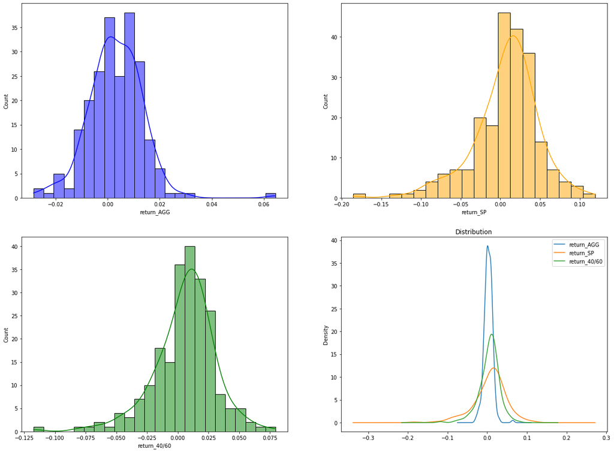

|  | return_AGG | return_SP | return_40/60 |
| --- | --- | --- | --- |
| count | 220.000000 | 220.000000 | 220.000000 |
| mean | 0.003017 | 0.006871 | 0.005547 |
| std | 0.010473 | 0.041663 | 0.025421 |
| skewness | 0.619203 | -0.902675 | -0.895205 |
| kurtosis | 7.925974 | 5.450257 | 5.969743 |
| excess kurtosis | 4.925974 | 2.450257 | 2.969743 |
| min | -0.028467 | -0.185636 | -0.117409 |
| 25% | -0.002510 | -0.015133 | -0.005460 |
| 50% | 0.002675 | 0.012126 | 0.008765 |
| 75% | 0.009437 | 0.031131 | 0.020155 |
| max | 0.064499 | 0.119421 | 0.079719 |

```python
# ------- Calculate_moment -------
def calculate_moment(X):
    X = pd.Series(X)
    X = X.dropna() # drop NA
    mu = np.mean(X)
    sigma = np.sqrt(  np.sum( (X - np.mean(X))**2 ) / (  len(X) -1 ) )
    skewness = np.sum( ( (X-mu)/sigma )**3 ) / (  len(X) -2 )
    kurtosis = np.sum( ( (X-mu)/sigma )**4 ) / (  len(X) -2 ) # minus 2 freedom
    excess_kurtosis = kurtosis -3
    return(pd.Series({
        'count': len(X),
        'mean': mu,
        'std': sigma, # the same as np.std( X, ddof=1 )
        'skewness': skewness,
        'kurtosis': kurtosis,
        'excess kurtosis': excess_kurtosis,
        'min': min(X),
        '25%': X.quantile(0.25),
        '50%': X.quantile(0.50),
        '75%': X.quantile(0.75),
        'max': max(X),
    }))

data_statistics_for__return =pd.DataFrame({
    'return_AGG': calculate_moment(data_month['return_AGG']),
    'return_SP': calculate_moment(data_month['return_SP']),
    'return_40/60': calculate_moment(data_month['return_40/60']),
})

# ------- Plot -------
fig, axs = plt.subplots(nrows=2,ncols=2,figsize=(20,15))
sns.histplot(ax=axs[0,0], x=data_month['return_AGG'],color='blue', kde=True, legend=True)
sns.histplot(ax=axs[0,1], x=data_month['return_SP'],color='orange', kde=True)
sns.histplot(ax=axs[1,0], x=data_month['return_40/60'],color='green', kde=True)
data_month[['return_AGG','return_SP','return_40/60']].plot.density(title='Distribution', ax=axs[1,1])  # !!!!!
plt.show()

# ------- Show data -------
data_statistics_for__return
```

### Q5:

If we had invested $100 in each portfolio, i.e. AGG, S&P, and 60/40, on 30/Sept/2003 and held till 31 Dec 2021, what would have been the largest loss experienced from each investment (i.e. maximum drawdown, aka MDD) and how long would they have taken to recover back to the peak of the assets prior to the MDD (i.e. recovery time back to high watermark)? [20 points]

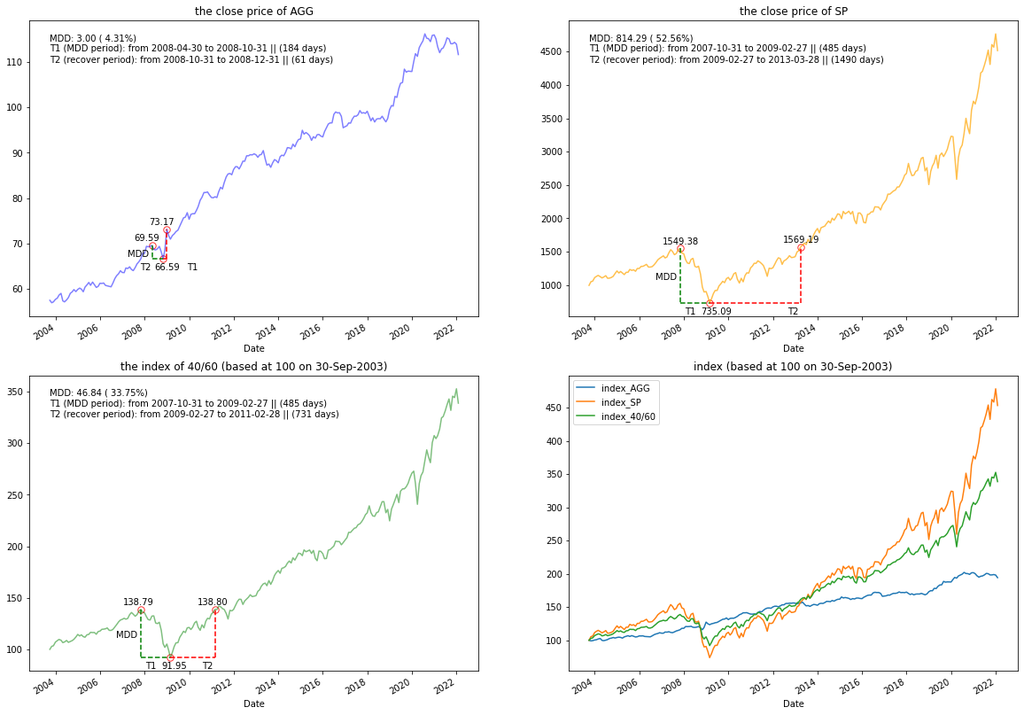

|  | close_AGG | close_SP | index_40/60 |
| --- | --- | --- | --- |
| MDD | 3.001473 | 814.29 | 46.837074 |
| MDD(%) | 4.31% | 52.56% | 33.75% |
| MDD_start_date | 2008-04-30 00:00:00 | 2007-10-31 00:00:00 | 2007-10-31 00:00:00 |
| MDD_peak_value | 69.589539 | 1549.38 | 138.786877 |
| MDD_end_date | 2008-10-31 00:00:00 | 2009-02-27 00:00:00 | 2009-02-27 00:00:00 |
| MDD_through_value | 66.588066 | 735.09 | 91.949803 |
| MDD_recover_date | 2008-12-31 00:00:00 | 2013-03-28 00:00:00 | 2011-02-28 00:00:00 |
| MDD_recover_value | 73.172386 | 1569.19 | 138.800444 |
| MDD_recover_period | 61 days 00:00:00 | 1490 days 00:00:00 | 731 days 00:00:00 |

```python
# ------- calculate_MDD -------
def calculate_MDD(df,symbol):
    df=df.copy()
    df['date'] = df.index
    df['previous_max'] = df['date'].apply(lambda x: np.max(df[df.index <= x][symbol]) )
    df['previous_max_date'] = df['date'].apply(lambda x: df['date'][np.argmax(df[df.index <= x][symbol])] )
    target_row = np.argmin( (df[symbol] - df['previous_max'])/df['previous_max'] )
    MDD = df['previous_max'][target_row] - df[symbol][target_row]
    MDD_percent = MDD / df['previous_max'][target_row]
    MDD_start_date = df['previous_max_date'][target_row]
    MDD_end_date = df.index[target_row]
    MDD_peak_value = df['previous_max'][target_row]
    MDD_through_value = df[symbol][target_row]
    df_after_MDD = df[ (df.index > MDD_end_date) & ( df[symbol] > MDD_peak_value ) ].copy()
    MDD_recover_date = df_after_MDD['date'][0] if df_after_MDD.shape[0] > 0 else np.NaN
    MDD_recover_value = df.loc[MDD_recover_date, symbol]
    MDD_recover_period = np.NaN if str(MDD_recover_date).lower() == 'nan' else (MDD_recover_date - MDD_end_date)
    return(pd.Series({
        'MDD': MDD,
        'MDD(%)': f"{MDD_percent: .2%}",
        'MDD_start_date': MDD_start_date,
        'MDD_peak_value': MDD_peak_value,
        'MDD_end_date': MDD_end_date,
        'MDD_through_value': MDD_through_value,
        'MDD_recover_date': MDD_recover_date,
        'MDD_recover_value': MDD_recover_value,
        'MDD_recover_period': MDD_recover_period
    }))

data_MDD_for_return = pd.DataFrame({
    'close_AGG': calculate_MDD(data_month,'close_AGG'),
    'close_SP': calculate_MDD(data_month,'close_SP'),
    'index_40/60': calculate_MDD(data_month,'index_40/60')
})


# ------- Plot -------
fig, axs = plt.subplots(nrows=2,ncols=2,figsize=(20,15))

# fig1
data['close_AGG'].plot.line(title='the close price of AGG', ax=axs[0,0], color = 'blue', alpha=0.5)

# fig2
data['close_SP'].plot.line(title='the close price of SP', ax=axs[0,1], color = 'orange', alpha=0.7)

# fig3
data_month['index_40/60'].plot.line(title='the index of 40/60 (based at 100 on 30-Sep-2003)', ax=axs[1,0], color = 'green', alpha=0.5)

# fig4
data_month[['index_AGG','index_SP', 'index_40/60']].plot.line(title='index (based at 100 on 30-Sep-2003)',ax = axs[1,1])

# ------- add decorations for charts -------
def plot_decoration(ax, symbol, df = data_MDD_for_return, df_text_info = data_month ):
    x_MDD_start_point = df.loc['MDD_start_date',symbol]
    y_MDD_start_point = df.loc['MDD_peak_value',symbol]
    x_MDD_end_point = df.loc['MDD_end_date',symbol]
    y_MDD_end_point = df.loc['MDD_through_value',symbol]
    x_MDD_recover_point = df.loc['MDD_recover_date',symbol]
    y_MDD_recover_point = df.loc['MDD_recover_value',symbol]
    MDD = df.loc['MDD',symbol]
    MDD_percentage = df.loc['MDD(%)',symbol]
    period_MDD =  x_MDD_end_point -x_MDD_start_point

    # add scatters
    ax.scatter( [x_MDD_start_point, x_MDD_end_point, x_MDD_recover_point],
                [y_MDD_start_point, y_MDD_end_point, y_MDD_recover_point],
                s=55, c='w', marker='o', edgecolors='r', alpha =0.8  )
    period_recover = x_MDD_recover_point -x_MDD_end_point

    # add annotates on scatters
    ax.annotate(f"{y_MDD_start_point:.2f}",
                  xy=(x_MDD_start_point, y_MDD_start_point),
                  xytext=(-20,+5),
                  fontsize=10,
                  textcoords='offset points') # peak point
    ax.annotate(f"{y_MDD_end_point:.2f}",
                  xy=(x_MDD_end_point, y_MDD_end_point),
                  xytext=(-10,-13),
                  fontsize=10,
                  textcoords='offset points') # through point
    ax.annotate(f"{y_MDD_recover_point:.2f}",
                    xy=(x_MDD_recover_point, y_MDD_recover_point),
                    xytext = (-20,+5),
                    fontsize = 10,
                    textcoords='offset points' )

    # add lines
    ax.plot([x_MDD_start_point, x_MDD_start_point], [y_MDD_start_point, y_MDD_end_point], 'g--')
    ax.plot([x_MDD_start_point, x_MDD_end_point], [y_MDD_end_point, y_MDD_end_point], 'g--')
    ax.plot([x_MDD_end_point, x_MDD_recover_point], [y_MDD_end_point, y_MDD_end_point], 'r--')
    ax.plot([x_MDD_recover_point, x_MDD_recover_point], [y_MDD_end_point, y_MDD_recover_point], 'r--')

    # add annotates on lines
    ax.annotate(f"MDD",
                  xy=(x_MDD_start_point, (y_MDD_start_point+y_MDD_end_point)/2 ),
                  xytext=(-28,-5),
                  fontsize=10,
                  textcoords='offset points') # through point
    if symbol !='close_AGG': # close_AGG has no recover_point, so we use if-statement here
        ax.annotate(f"T2",
                  xy=(x_MDD_recover_point, y_MDD_end_point ),
                  xytext=(-15,-13),
                  fontsize=10,
                  textcoords='offset points') # through point
        ax.annotate(f"T1",
                  xy=(x_MDD_start_point, y_MDD_end_point ),
                  xytext=(+5,-13),
                  fontsize=10,
                  textcoords='offset points') # through point
    else:
        ax.annotate(f"T2",
                  xy=(x_MDD_recover_point, y_MDD_end_point ),
                  xytext=(-30,-13),
                  fontsize=10,
                  textcoords='offset points') # through point
        ax.annotate(f"T1",
                  xy=(x_MDD_start_point, y_MDD_end_point ),
                  xytext=(+40,-13),
                  fontsize=10,
                  textcoords='offset points') # through point

    # add text on the left-top
    text = ( f"MDD: {np.abs(MDD):.2f} ({MDD_percentage})\n" +
             f"T1 (MDD period): from {x_MDD_start_point.strftime('%Y-%m-%d')} to {x_MDD_end_point.strftime('%Y-%m-%d')} || ({period_MDD.days} days)\n"  +
             f"T2 (recover period): from {x_MDD_end_point.strftime('%Y-%m-%d')} to {x_MDD_recover_point.strftime('%Y-%m-%d')} || ({period_recover.days} days)"
            )
    ax.text(df_text_info.index[0], df_text_info[symbol].max(),
            verticalalignment = "top",
            horizontalalignment="left",
            fontsize = 10,
            s=text)

# ------- call functions -------
plot_decoration(ax=axs[0,0], symbol='close_AGG', df=data_MDD_for_return, df_text_info=data_month)
plot_decoration(ax=axs[0,1], symbol='close_SP', df=data_MDD_for_return, df_text_info=data_month)
plot_decoration(ax=axs[1,0], symbol='index_40/60', df=data_MDD_for_return, df_text_info=data_month)

plt.show()


# ------- show -------
data_MDD_for_return
```

### Q6:

If we had invested $100 in 60/40 on 30/Sept/2003 and left the investment untouched without rebalancing it back to 60/40, what would be the investment outcome and how does this compare with the monthly rebalanced 60/40 portfolio as seen above? [20 points]

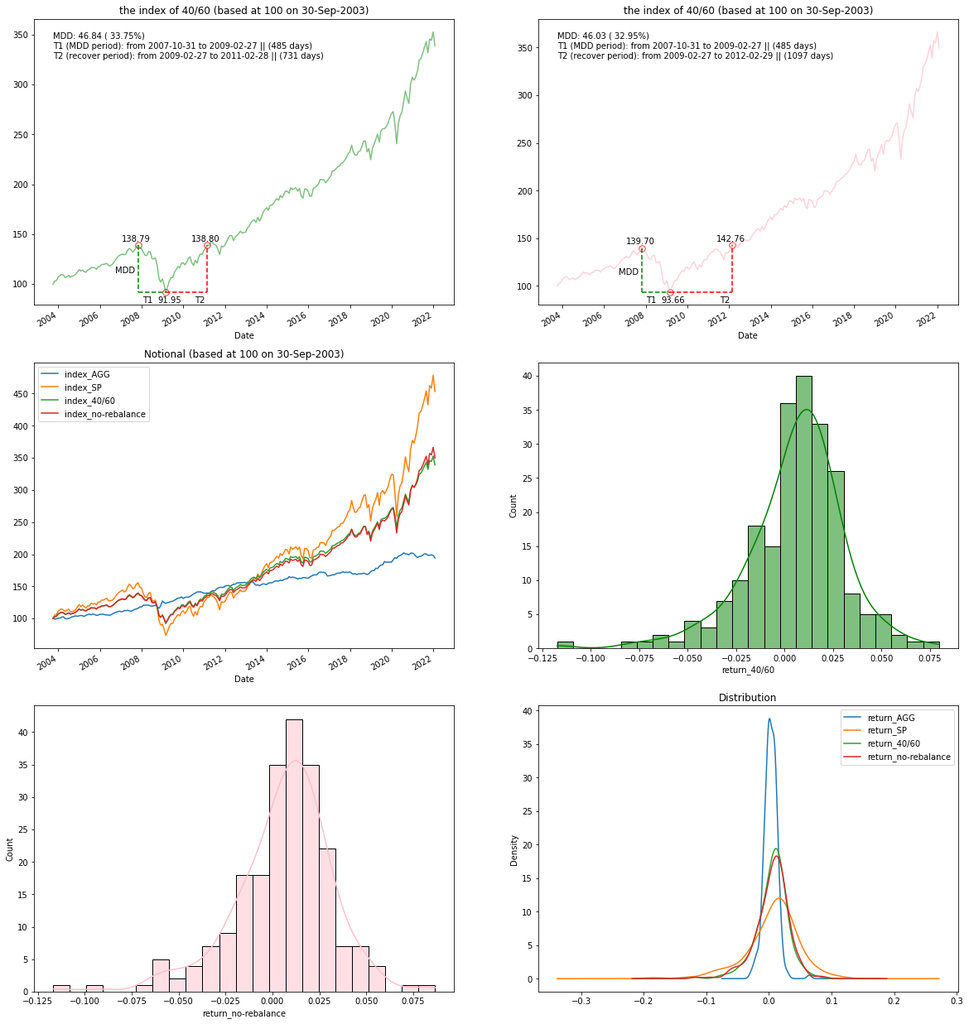

| Date | close_AGG | close_SP | return_AGG | return_SP | return_40/60 | index_AGG | index_SP | index_40/60 | index_no-rebalance | weight_AGG | weight_SP | return_no-rebalance |
| --- | --- | --- | --- | --- | --- | --- | --- | --- | --- | --- | --- | --- |
| 2003-09-30 | 57.482021 | 995.97 | NaN | NaN | NaN | 100.000000 | 100.000000 | 100.000000 | 100.000000 | 0.400000 | 0.600000 | NaN |
| 2003-10-31 | 56.944702 | 1050.71 | -0.009392 | 0.053504 | 0.028819 | 99.065240 | 105.496149 | 102.923786 | 102.923786 | 0.385004 | 0.614996 | 0.028819 |
| 2003-11-28 | 57.135136 | 1058.20 | 0.003339 | 0.007103 | 0.005599 | 99.396533 | 106.248180 | 103.501681 | 103.507521 | 0.384113 | 0.615887 | 0.005656 |
| 2003-12-31 | 57.694630 | 1111.92 | 0.009745 | 0.049519 | 0.033799 | 100.369870 | 111.641917 | 107.059681 | 107.133098 | 0.374748 | 0.625252 | 0.034428 |
| 2004-01-30 | 57.948776 | 1131.13 | 0.004395 | 0.017129 | 0.012055 | 100.812002 | 113.570690 | 108.358086 | 108.467215 | 0.371769 | 0.628231 | 0.012376 |
| ... | ... | ... | ... | ... | ... | ... | ... | ... | ... | ... | ... | ... |
| 2021-09-30 | 114.026978 | 4307.54 | -0.009215 | -0.048738 | -0.032741 | 198.369814 | 432.496963 | 331.841752 | 338.846103 | 0.234171 | 0.765829 | -0.039622 |
| 2021-10-29 | 114.017029 | 4605.38 | -0.000087 | 0.066858 | 0.040615 | 198.352506 | 462.401478 | 345.597065 | 356.781889 | 0.222380 | 0.777620 | 0.051579 |
| 2021-11-30 | 114.325836 | 4567.00 | 0.002705 | -0.008369 | -0.003925 | 198.889729 | 458.547948 | 344.243407 | 354.684661 | 0.224300 | 0.775700 | -0.005896 |
| 2021-12-31 | 113.915718 | 4766.18 | -0.003594 | 0.042689 | 0.024432 | 198.176258 | 478.546543 | 352.757516 | 366.398429 | 0.216351 | 0.783649 | 0.032492 |
| 2022-01-31 | 111.639008 | 4515.55 | -0.020188 | -0.054018 | -0.040349 | 194.215523 | 453.382130 | 338.807572 | 349.715487 | 0.222141 | 0.777859 | -0.046601 |

221 rows × 12 columns

```python
# ------- build the no rebalance portfolio -------
# calculate the quantity
data_month_expend = data_month.copy()
quantity_AGG = 100 * 0.4 / data['close_AGG'][0]
quantity_SP = 100 * 0.6 / data['close_SP'][0]

# calculate the no-rebalance portfolio value
data_month_expend['index_no-rebalance'] = quantity_AGG * data_month_expend['close_AGG'] + quantity_SP* data_month_expend['close_SP']

# calculate the weight
data_month_expend['weight_AGG'] = (quantity_AGG * data_month_expend['close_AGG']) / data_month_expend['index_no-rebalance']
data_month_expend['weight_SP'] =  (quantity_SP * data_month_expend['close_SP']) / data_month_expend['index_no-rebalance']

# calculate the return of no-rebalance portfolio
data_month_expend['return_no-rebalance'] = np.log( data_month_expend['weight_AGG'].shift(1) * np.exp(data_month_expend['return_AGG']) +
                                                   data_month_expend['weight_SP'].shift(1) * np.exp(data_month_expend['return_SP']) )
#data_month_expend['no-rebalance_'] = 100 * np.exp( data_month_expend['return_no-rebalance'].cumsum() ) # for test the portfolio return
#data_month_expend.loc[data_month_expend.index[0],'no-rebalance'] = 100


# ------- Compare the no rebalance portfolio & 40/60 rebalance portfolio -------
# ------- (1) Plot: Line Charts & MDD -------
data_MDD_for_return_expand = pd.DataFrame({
    'close_AGG': calculate_MDD(data_month_expend,'close_AGG'),
    'close_SP': calculate_MDD(data_month_expend,'close_SP'),
    'index_40/60': calculate_MDD(data_month_expend,'index_40/60'),
    'index_no-rebalance': calculate_MDD(data_month_expend,'index_no-rebalance')
})

fig, axs = plt.subplots(nrows=3,ncols=2,figsize=(20,24))

# fig1
data_month_expend['index_40/60'].plot.line(title='the index of 40/60 (based at 100 on 30-Sep-2003)', ax=axs[0,0], color = 'green', alpha=0.5)
plot_decoration(ax=axs[0,0], symbol='index_40/60', df=data_MDD_for_return_expand, df_text_info=data_month_expend)

# fig2
data_month_expend['index_no-rebalance'].plot.line(title='the index of 40/60 (based at 100 on 30-Sep-2003)', ax=axs[0,1], color = 'pink', alpha=0.7)
plot_decoration(ax=axs[0,1], symbol='index_no-rebalance', df=data_MDD_for_return_expand, df_text_info=data_month_expend)

# fig3
data_month_expend[['index_AGG','index_SP', 'index_40/60','index_no-rebalance']].plot.line(title='Notional (based at 100 on 30-Sep-2003)', ax=axs[1,0])

# fig4
sns.histplot(ax=axs[1,1], x=data_month_expend['return_40/60'],color='green', kde=True)

# fig5
sns.histplot(ax=axs[2,0], x=data_month_expend['return_no-rebalance'],color='pink', kde=True)

# fig6
data_month_expend[['return_AGG','return_SP','return_40/60','return_no-rebalance']].plot.density(title='Distribution', ax=axs[2,1])  # !!!!!

plt.show()


data_month_expend
```

```python
data_statistics_for__return_expand =pd.DataFrame({
    'return_AGG': calculate_moment(data_month_expend['return_AGG']),
    'return_SP': calculate_moment(data_month_expend['return_SP']),
    'return_40/60': calculate_moment(data_month_expend['return_40/60']),
    'return_no-rebalance': calculate_moment(data_month_expend['return_no-rebalance']),
})
data_statistics_for__return_expand
```

|  | return_AGG | return_SP | return_40/60 | return_no-rebalance |
| --- | --- | --- | --- | --- |
| count | 220.000000 | 220.000000 | 220.000000 | 220.000000 |
| mean | 0.003017 | 0.006871 | 0.005547 | 0.005691 |
| std | 0.010473 | 0.041663 | 0.025421 | 0.026564 |
| skewness | 0.619203 | -0.902675 | -0.895205 | -0.879008 |
| kurtosis | 7.925974 | 5.450257 | 5.969743 | 5.720647 |
| excess kurtosis | 4.925974 | 2.450257 | 2.969743 | 2.720647 |
| min | -0.028467 | -0.185636 | -0.117409 | -0.116926 |
| 25% | -0.002510 | -0.015133 | -0.005460 | -0.006024 |
| 50% | 0.002675 | 0.012126 | 0.008765 | 0.009408 |
| 75% | 0.009437 | 0.031131 | 0.020155 | 0.021549 |
| max | 0.064499 | 0.119421 | 0.079719 | 0.086573 |

- Conclusion of Q6: Accoding to distuibution charts and statistical properties:
1. The 40/60 portfolio and no-rebalance portfolio have similar performance and risk.
2. The no-rebalance portfolio have has higher performance(mean) and risk(std) than 40/60 portfolio.
3. They have similar kurtosis and skewness, which means they have similar tail risk.